# DSC1107_MONFERO_SA1

### Data Visualization

> Create at least three meaningful visualizations to explore relationships in the data (e.g., churn rate by tenure, service type, or monthly charges).

> Provide insights based on the visualizations.

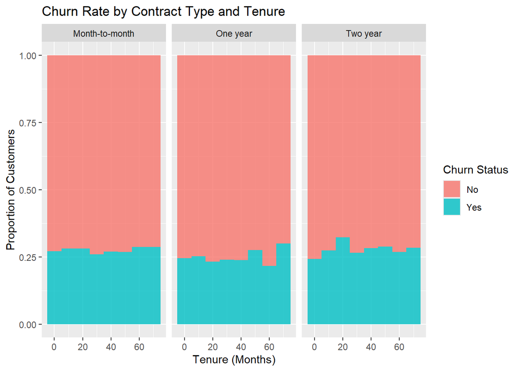

```r
data %>%
  ggplot(aes(x = Tenure, fill = Churn)) +
  geom_histogram(binwidth = 10, position = "fill", alpha = 0.80) +
  facet_wrap(~Contract) +
  labs(
    title = "Churn Rate by Contract Type and Tenure",
       x = "Tenure (Months)",
       y = "Proportion of Customers",
       fill = "Churn Status"
    )
```

```r
cat("The first multivariable visualization suggests that the churn rate is rather relatively consistent across different contract types {Month-to-Month; One Year; Two Year}, with approximately 75% of customers retaining their subscription (No churn) and 25% opting to leave (Yes churn), irrespective of their tenure length, the proportion remains constant. This indicates that other factors, beyond the duration of tenure, might play a better and more significant role in determining customer churn.")
```

```
## The first multivariable visualization suggests that the churn rate is rather relatively consistent across different contract types {Month-to-Month; One Year; Two Year}, with approximately 75% of customers retaining their subscription (No churn) and 25% opting to leave (Yes churn), irrespective of…
```

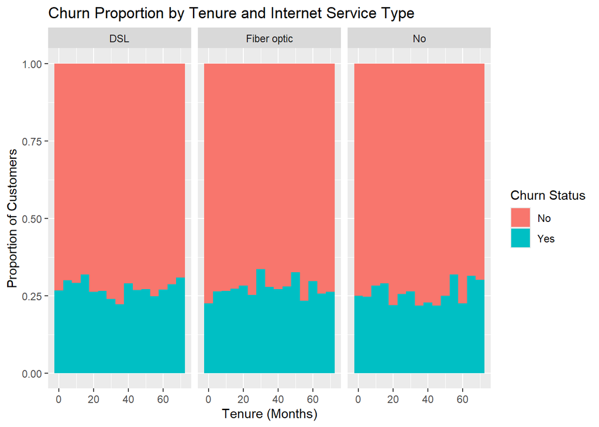

```r
data %>%
  ggplot(aes(x = Tenure, fill = Churn)) +
  geom_histogram(binwidth = 5, position = "fill") +
  facet_wrap(~InternetService) +
  labs(
    title = "Churn Proportion by Tenure and Internet Service Type",
    x = "Tenure (Months)",
    y = "Proportion of Customers",
    fill = "Churn Status"
  )
```

```r
cat("The data visualization suggests that the churn rate is rather independent across different Internet Service Types {DSL; Fiber Optic; No}, with approximately 70-75% of customers retaining their subscription (No churn) and 25-30% opting to leave (Yes churn), very weak influenced by their tenure length, the proportion remains independent. This indicates that other factors or other interactions of variables, beyond the duration of tenure, might play a better and more significant role in determining customer churn.")
```

```
## The data visualization suggests that the churn rate is rather independent across different Internet Service Types {DSL; Fiber Optic; No}, with approximately 70-75% of customers retaining their subscription (No churn) and 25-30% opting to leave (Yes churn), very weak influenced by their tenure len…
```

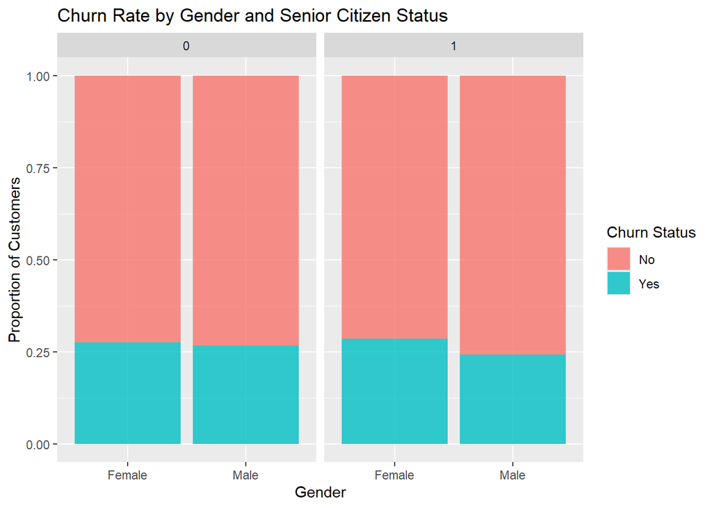

```r
data %>%
  ggplot(aes(x = Gender, fill = Churn)) +
  geom_bar(position = "fill", alpha = 0.8) +
  facet_wrap(~SeniorCitizen) +
  labs(
    title = "Churn Rate by Gender and Senior Citizen Status",
    x = "Gender",
    y = "Proportion of Customers",
    fill = "Churn Status"
  )
```

```r
cat("In this visualization, there are exactly no difference of churn rate whenever their customer is not a Senior Citizen, only on the other hand, slightly more females but not to an alarming proportions, they tend to cut subscriptions (Churn Yes) when they are a Senior Citizen.")
```

```
## In this visualization, there are exactly no difference of churn rate whenever their customer is not a Senior Citizen, only on the other hand, slightly more females but not to an alarming proportions, they tend to cut subscriptions (Churn Yes) when they are a Senior Citizen.
```

### Data Wrangling

> Use Boxplot to detect outliers visually

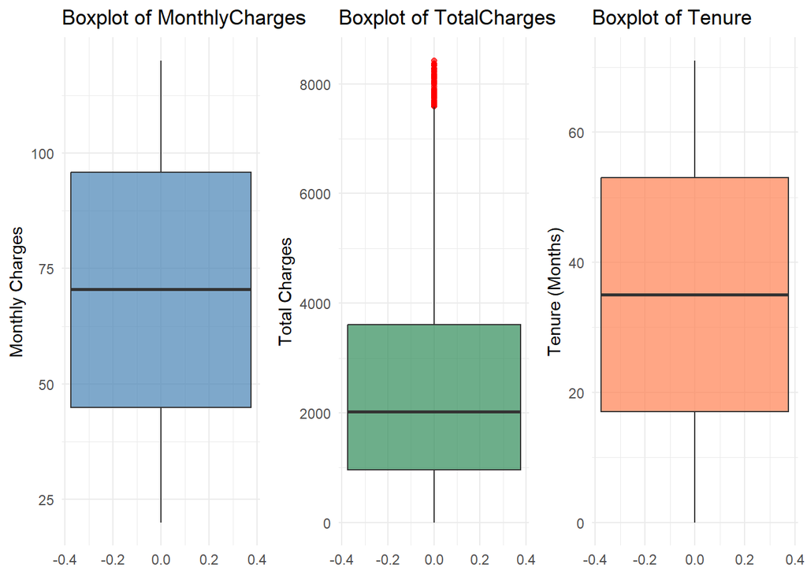

```r
# Boxplot for MonthlyCharges
boxplot1 <- data %>%
  ggplot(aes(y = MonthlyCharges)) +
  geom_boxplot(fill = "steelblue", alpha = 0.7, outlier.color = "red") +
  labs(
    title = "Boxplot of MonthlyCharges",
    y = "Monthly Charges"
  ) +
  theme_minimal()

# Boxplot for TotalCharges
boxplot2 <- data %>%
  ggplot(aes(y = TotalCharges)) +
  geom_boxplot(fill = "seagreen", alpha = 0.7, outlier.color = "red") +
  labs(
    title = "Boxplot of TotalCharges",
    y = "Total Charges"
  ) +
  theme_minimal()

# Boxplot for Tenure
boxplot3 <- data %>%
  ggplot(aes(y = Tenure)) +
  geom_boxplot(fill = "coral", alpha = 0.7, outlier.color = "red") +
  labs(
    title = "Boxplot of Tenure",
    y = "Tenure (Months)"
  ) +
  theme_minimal()

# Combine the boxplots using cowplot
combined_boxplots <- plot_grid(
  boxplot1, boxplot2, boxplot3,
  nrow = 1,
  ncol = 3 # Arrange plots horizontally
)

# Display the combined boxplots
print(combined_boxplots)
```

```r
cat("This suggests that there are some outliers observed in the variable `TotalCharges` from the provided dataset")
```

```
## This suggests that there are some outliers observed in the variable `TotalCharges` from the provided dataset
```

> Filter data to remove outliers. Recall the Concept of IQR (Inter-Quartile Range)

```r
# Calculate the IQR for TotalCharges
Q1 <- quantile(data$TotalCharges, 0.25, na.rm = TRUE)  # First quartile (25th percentile)
Q3 <- quantile(data$TotalCharges, 0.75, na.rm = TRUE)  # Third quartile (75th percentile)
IQR <- Q3 - Q1  # Interquartile range

# Define the lower and upper bounds for outliers
lower_bound <- Q1 - 1.5 * IQR
upper_bound <- Q3 + 1.5 * IQR

# Filter the data to remove outliers
data_no_outliers <- data %>%
  filter(TotalCharges >= lower_bound & TotalCharges <= upper_bound)

# Display the cleaned dataset
glimpse(data_no_outliers)
```

```
## Rows: 9,928
## Columns: 12
## $ CustomerID      <chr> "CUST00001", "CUST00002", "CUST00003", "CUST00004", "C…
## $ Gender          <fct> Male, Male, Male, Female, Male, Female, Female, Female…
## $ SeniorCitizen   <int> 0, 0, 0, 0, 0, 0, 0, 0, 0, 0, 0, 0, 1, 0, 0, 0, 0, 0, …
## $ Partner         <fct> No, No, Yes, Yes, No, No, Yes, Yes, Yes, No, No, No, N…
## $ Dependents      <fct> No, No, No, Yes, No, Yes, No, Yes, Yes, No, No, No, No…
## $ Tenure          <int> 65, 26, 54, 70, 53, 45, 35, 20, 48, 33, 33, 39, 6, 51,…
## $ PhoneService    <fct> Yes, Yes, Yes, Yes, Yes, Yes, Yes, Yes, No, Yes, Yes, …
## $ InternetService <fct> Fiber optic, Fiber optic, Fiber optic, DSL, DSL, Fiber…
## $ Contract        <fct> Month-to-month, Month-to-month, Month-to-month, One ye…
## $ MonthlyCharges  <dbl> 20.04, 65.14, 49.38, 31.19, 103.86, 87.34, 119.91, 69.…
## $ TotalCharges    <dbl> 1302.60, 1693.64, 2666.52, 2183.30, 5504.58, 3930.30, …
## $ Churn           <fct> No, No, No, No, Yes, Yes, Yes, Yes, No, No, Yes, No, N…
```

### Review

> In this first chapter, we are able to demonstrate the ability and apply data mining techniques: such as displaying powerful data visualization, and some tidying some data wrangling and transformation.

> Use relevant and accurate type of plots (by knowing data types first) and algorithms that are needed in order to normalized (Min-Max Scale), and remove any outliers (IQR).

### Save the tidy dataset for future use

```r
# Save the data_no_outliers dataset as a CSV file
write.csv(data_no_outliers, file = "CUSTOMER_CHURN_TIDY.CSV", row.names = FALSE)
```